# Spatial Autocorrelation and Regression in R

## Introduction

Recall that one of the key assumptions of OLS regression is independence of residuals. In a problem with a spatial component, a violation of independence of residuals means that there might be certain parts of our study area where there is systematic over- or under-prediction. This is obviously a problem, and this is why there are methods – such as Spatial Lag, Spatial Error, and Geographically Weighted Regression – to account for spatial autocorrelation in the residuals.

For the example here, we will be using the files used for HW 1 and HW2. We will use Median Household Income as the dependent variable, and Median House Value and % of Vacant Housing Units as predictors.

Prior to running anything, we will set the working directory below. You may change it to where the files are stored on your computer.

## Packages

In this tutorial you will use - the `sp`, `rgdal` and `rgeos` packages to process `SpatialPolygonDataFrame` datasets - the `spdep` package to generate measures of spatial autocorrelation. The package `spatialreg` is used to run Spatial Lag and Spatial Error analyses and the `spgwr` package to run geographically weighted regression analyses. The `tmap` package is needed to map our data. Finally, the `lmtest`, `whitestrap` and `tseries` packages are used for tests of heteroscedasticity and normality of residuals. You will need to make sure that these packages are installed prior to running the library statements below.

```r
options(scipen=999)

#install.packages(c("sp", "sf" "rgdal", "rgeos", "spdep", "spgwr", "tmap", "spatialreg", "lmtest", "whitestrap", "tseries"))

library(sf)
#library(rgeos)
library(spdep)
library(spgwr)
library(tmap)
library(spatialreg)
library(whitestrap)
library(lmtest)
library(tseries)
```

```r
shp <-st_read(dsn ="C:\\Users\\eugeneby\\Dropbox\\Documents\\Work and School\\Teaching\\CPLN 671 - Statistics and Data Mining\\2023_MUSA_5000_GitHub\\Homework Assignments\\HW 1\\Lecture 1 - RegressionData.shp")
```

Before proceeding, let’s examine the distributions of our variables and see whether we need to create log transformations of any of them.

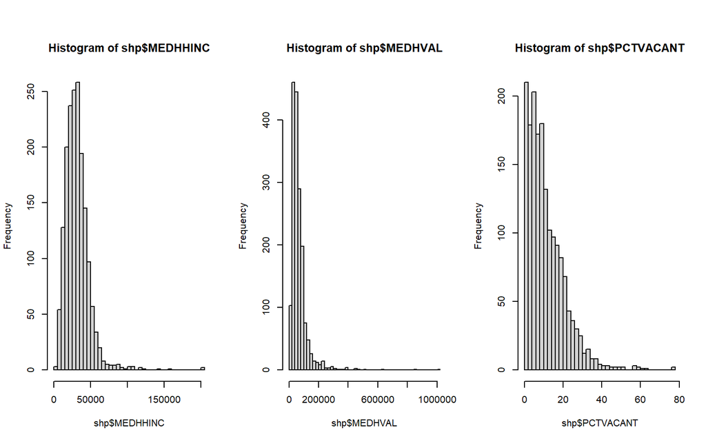

```r
par(oma=c(0,0,2,0))
par(mfrow=c(1,3))
hist(shp$MEDHHINC, breaks = 50)
hist(shp$MEDHVAL, breaks = 50)
hist(shp$PCTVACANT, breaks = 50)
```

It seems that the MEDHHINC and MEDHVAL variables can benefit from logarithmic transformations, whereas the spike at 0 for PCTVACANT doesn’t make the transformation useful.

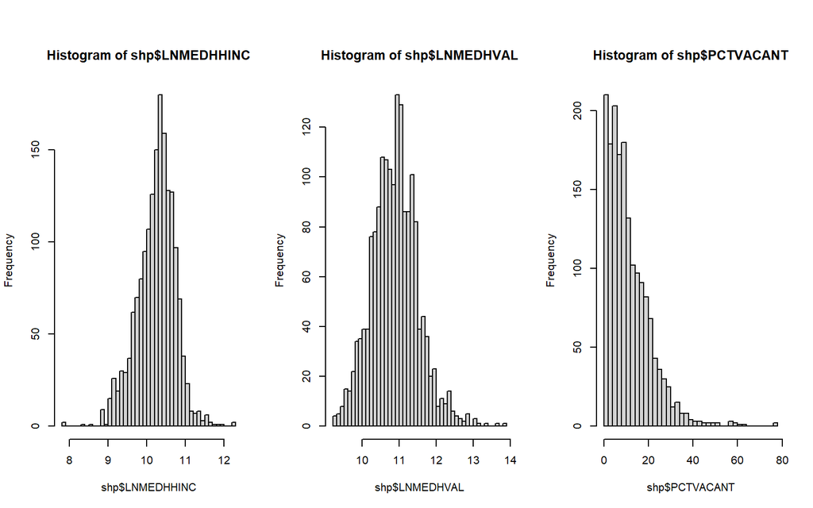

```r
shp$LNMEDHVAL <- log(shp$MEDHVAL + 1)
shp$LNMEDHHINC <- log(shp$MEDHHINC + 1)
shp$LNPCTVACANT <- log(shp$PCTVACANT + 1)

par(oma=c(0,0,2,0))
par(mfrow=c(1,3))
hist(shp$LNMEDHHINC, breaks = 50)
hist(shp$LNMEDHVAL, breaks = 50)
hist(shp$PCTVACANT, breaks = 50)
```

This means that we will regress LNMEDHHINC on LNMEDHVAL and PCTVACANT.

## Defining Neighbors

The very premise of spatial autocorrelation lies in the observation that near things are more similar to one another than to things farther away. This is Tobler’s First Law of Geography. Therefore, we begin by defining neighbors for each of the block groups in Philadelphia. Here, we will be using Queen Neighbors.

```r
queen<-poly2nb(shp, row.names=shp$POLY_ID)
summary(queen)
```

```
## Neighbour list object:
## Number of regions: 1720
## Number of nonzero links: 10526
## Percentage nonzero weights: 0.3558004
## Average number of links: 6.119767
## Link number distribution:
##
##   1   2   3   4   5   6   7   8   9  10  11  12  13  14  15  16  18  27
##   4  16  52 175 348 493 344 177  62  28  10   4   2   1   1   1   1   1
## 4 least connected regions:
## 441 708 1391 1665 with 1 link
## 1 most connected region:
## 1636 with 27 links
```

We can see that the number of queen neighbors each block group has ranges between 1 and 27, with the mode being 6. Fortunately for our analysis, all block groups have at least one neighbor. We always need to check to make sure that we don’t have any block groups without any neighbors. We can also plot out the neighbor relationships to check that the queen specification did indeed work.

It is useful to examine where block groups with non-average neighbor patterns are situated before we run spatial analyses. This is because these outlier block groups will affect our spatial analyses. We will look at the block groups where there is only 1 neighbor, and block groups where there are 27 neighbors. The block groups themselves will be colored in red, and their neighbors in green.

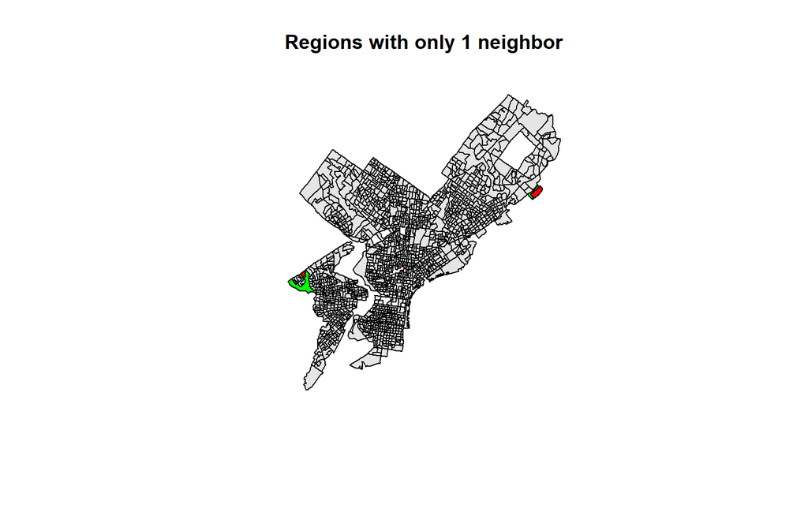

```r
#see which region has only one neighbor
smallestnbcard<-card(queen) #extract neighbor matrix
smallestnb<-which(smallestnbcard == min(smallestnbcard)) #extract block groups with smallest number of neighbors
fg<-rep('grey90', length(smallestnbcard))
fg[smallestnb]<-'red' #color block groups red
fg[queen[[smallestnb[1]]]]<-'green' #color neighboring blocks green
fg[queen[[smallestnb[2]]]]<-'green'
fg[queen[[smallestnb[3]]]]<-'green'
fg[queen[[smallestnb[4]]]]<-'green'
plot(shp$geometry, col=fg)
title(main='Regions with only 1 neighbor')
```

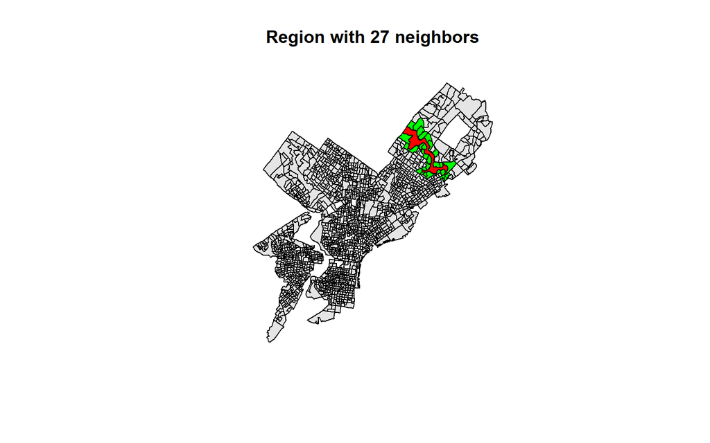

```r
#see which region has most neighbors
largestnbcard<-card(queen)
largestnb<-which(largestnbcard == max(largestnbcard))
fg1<-rep('grey90', length(largestnbcard))
fg1[largestnb]<-'red'
fg1[queen[[largestnb]]]<-'green'
plot(shp$geometry, col=fg1)
title(main='Region with 27 neighbors')
```

## Global Moran’s I

First, let’s create a Spatial Weights for Neighbors Lists using `nb2listw` function on the queen neighbors object we created earlier. We also specify the style parameter in this function to be `'W'`, which carries out row standardisation - each neighbor weight for a block group is divided by the sum of all neighbor weights for that same block group. This is recommended in our case where the distribution of our block groups and neighbors might potentially be biased given that block groups are ultimately units that are arbitrarily defined. We can then use the `moran` function to compute a Global Moran’s I statistic for our dependent variable LNMEDHHINC.

```r
queenlist<-nb2listw(queen, style = 'W')
moran(shp$LNMEDHHINC, queenlist, n=length(queenlist$neighbours), S0=Szero(queenlist))$`I`
```

```
## [1] 0.5524697
```

We see that there seems to be strong spatial autocorrelation in our dependent variable. We can check if this measure is statistically significant using the `moran.mc` function, and draw a histogram of the Moran’s I values from random permutations, as in GeoDa.

```r
moranMC<-moran.mc(shp$LNMEDHHINC, queenlist, nsim=999, alternative="two.sided")  #We use 999 permutations
moranMC
```

```
##
##  Monte-Carlo simulation of Moran I
##
## data:  shp$LNMEDHHINC
## weights: queenlist
## number of simulations + 1: 1000
##
## statistic = 0.55247, observed rank = 1000, p-value <
## 0.00000000000000022
## alternative hypothesis: two.sided
```

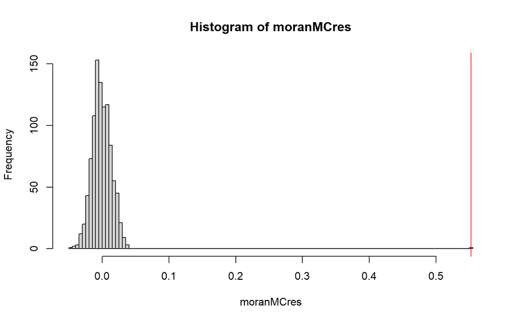

```r
moranMCres<-moranMC$res
hist(moranMCres, freq=10000000, nclass=100)   #Draws distribution of Moran's I's calculated from randomly permuted values
# Here, we draw a red vertical line at the observed value of our Moran's I
abline(v=moran(shp$LNMEDHHINC, queenlist, n=length(queenlist$neighbours), S0=Szero(queenlist))$`I`, col='red')
```

We can see that the value of Moran’s I in our data set (0.55) is much higher than the values shown in the histogram of Moran’s I values generated from random permutations.

If the above were not sufficiently convincing, we can also create a plot to visualise the relationship between the LNMEDHHINC of the block groups and their neighbors. If there is no spatial autocorrelation i.e. there is no relationship between block group observations and those of their neighbors, there should not be a clear pattern in the plot below. However, we observe that this is not the case.

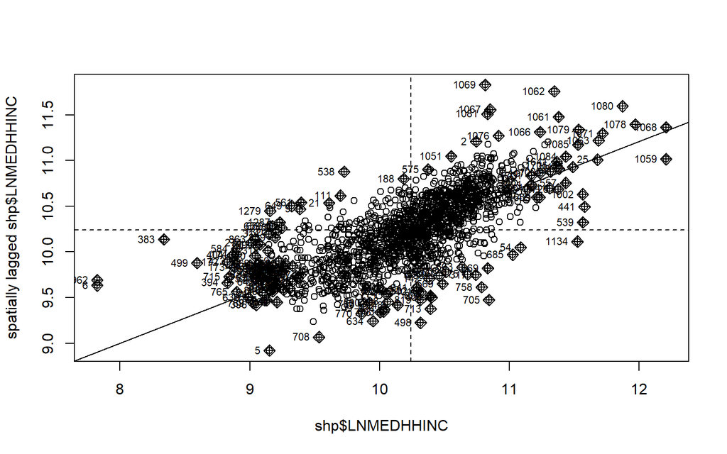

```r
#Create Moran plot (lagged value against observed value)
moran.plot(shp$LNMEDHHINC, queenlist)
```

## Local Moran’s I

The `localmoran` function allows us to compute LISA statistics for each block group. This function generates the Local Moran statistic as `Ii`. We might also be interested in `Var.Ii`, which tells us how much each block group’s Local Moran Statistic varies from the global mean, and `Pr(z>0)`, which indicates whether the Local Moran Statistic can be considered statistically significant.

```r
#Run local moran's I (LISA)
LISA<-localmoran(shp$LNMEDHHINC, queenlist)
head(LISA)
```

```
##            Ii            E.Ii      Var.Ii      Z.Ii Pr(z != E(Ii))
## 1  1.34570600 -0.000752009624 0.322556726  2.370772  0.01775098438
## 2  1.99981314 -0.000602061664 0.206502600  4.402074  0.00001072207
## 3 -0.08417305 -0.000004733151 0.001158936 -2.472401  0.01342087979
## 4  0.78134098 -0.000766738038 0.218990508  1.671298  0.09466280589
## 5  5.99000882 -0.002871544495 1.639713515  4.680062  0.00000286788
## 6  6.12194808 -0.014111319732 7.967036898  2.173908  0.02971205251
```

```r
df.LISA <-cbind(shp, as.data.frame(LISA))
```

Now, let’s look to see where there is significant spatial autocorrelation.

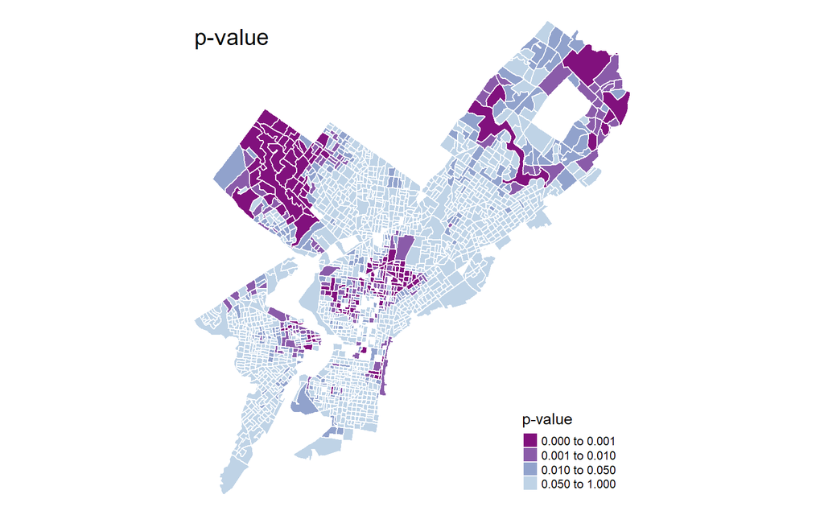

```r
moranSig.plot<-function(df,listw, title){
  local<-localmoran(x=df$LNMEDHHINC, listw=listw, zero.policy = FALSE)
  moran.map<-cbind(df, local)
  #Here, col='Pr.z....E.Ii..' is the name of the column in the dataframe df.LISA that we're trying to plot. This variable name might change based on the version of the package.
  tm<-tm_shape(moran.map)+
    tm_borders(col='white')+
    tm_fill(style='fixed', col='Pr.z....E.Ii..', breaks=c(0,0.001, 0.01, 0.05, 1), title= 'p-value', palette = '-BuPu')+
    tm_layout(frame = FALSE, title = title)
  print(tm)
}
moranSig.plot(df.LISA, queenlist, 'p-value')
```

Another useful map is below.

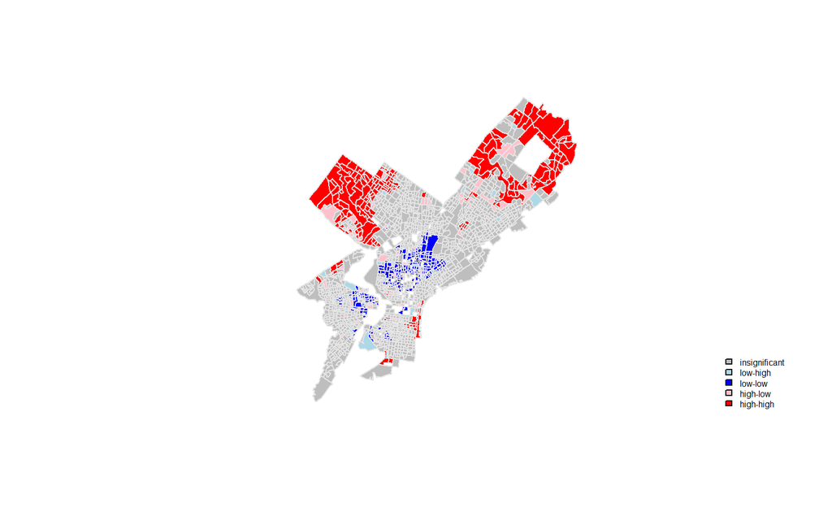

```r
hl.plot<-function(df, listw){
  local<-localmoran(x=df$LNMEDHHINC, listw=listw, zero.policy = FALSE)
  quadrant<-vector(mode='numeric', length=323)
  m.prop<-df$LNMEDHHINC - mean(df$LNMEDHHINC)
  m.local<-local[,1]-mean(local[,1])
  signif<-0.05
  quadrant[m.prop >0 & m.local>0]<-4 #high MEDHHINC, high clustering
  quadrant[m.prop <0 & m.local<0]<-1 #low MEDHHINC, low clustering
  quadrant[m.prop <0 & m.local>0]<-2 #low MEDHINC, high clustering
  quadrant[m.prop >0 & m.local<0]<-3 #high MEDHHINC, low clustering
  quadrant[local[,5]>signif]<-0

  brks <- c(0,1,2,3,4)
  colors <- c("grey","light blue",'blue','pink',"red")
  plot<-plot(shp$geometry,border="gray90",lwd=1.0,col=colors[findInterval(quadrant,brks,all.inside=FALSE)])
}

hl.plot(shp, queenlist)
legend("bottomright",legend=c("insignificant","low-high","low-low","high-low","high-high"),
       fill=c("grey", "light blue", "blue", "pink", "red"),bty="n", cex = 0.5)
```

## Regression Analysis: OLS Regression

First, let’s run an OLS regression. The `logLik` command prints the log likelihood. We can also run the same tests for heteroscedasticity and normality of residuals that we see in the GeoDa output.

```r
reg<-lm(formula=LNMEDHHINC ~ LNMEDHVAL + PCTVACANT, data=shp)
summary(reg)
```

```
##
## Call:
## lm(formula = LNMEDHHINC ~ LNMEDHVAL + PCTVACANT, data = shp)
##
## Residuals:
##      Min       1Q   Median       3Q      Max
## -2.53728 -0.15948  0.04741  0.22820  1.26485
##
## Coefficients:
##              Estimate Std. Error t value            Pr(>|t|)
## (Intercept)  5.650956   0.185321   30.49 <0.0000000000000002 ***
## LNMEDHVAL    0.431546   0.016411   26.30 <0.0000000000000002 ***
## PCTVACANT   -0.009191   0.001074   -8.56 <0.0000000000000002 ***
## ---
## Signif. codes:  0 '***' 0.001 '**' 0.01 '*' 0.05 '.' 0.1 ' ' 1
##
## Residual standard error: 0.3676 on 1717 degrees of freedom
## Multiple R-squared:  0.441,  Adjusted R-squared:  0.4403
## F-statistic: 677.3 on 2 and 1717 DF,  p-value: < 0.00000000000000022
```

```r
#Prints the log likelihood
logLik(reg)
```

```
## 'log Lik.' -717.6489 (df=4)
```

```r
#Prints the results of the Breusch-Pagan Test to assess whether heteroscedasticity is present (package: lmtest)
bptest(reg, studentize=FALSE)
```

```
##
##  Breusch-Pagan test
##
## data:  reg
## BP = 68.649, df = 2, p-value = 0.000000000000001239
```

```r
#Prints the results of the Koenker-Bassett Test (also known as the Studentized Breusch-Pagan Test) to assess whether heteroscedasticity is present (package: lmtest)
bptest(reg)
```

```
##
##  studentized Breusch-Pagan test
##
## data:  reg
## BP = 20.892, df = 2, p-value = 0.00002906
```

```r
#Prints the results of the White Test to assess whether heteroscedasticity is present (package: whitestrap)
white_test(reg)
```

```
## White's test results
##
## Null hypothesis: Homoskedasticity of the residuals
## Alternative hypothesis: Heteroskedasticity of the residuals
## Test Statistic: 52.48
## P-value: 0
```

```r
#Prints the results of the Jarque-Bera Test to assess whether residuals are normal (package: tseries)
jarque.bera.test(reg$residuals)
```

```
##
##  Jarque Bera Test
##
## data:  reg$residuals
## X-squared = 2012.4, df = 2, p-value < 0.00000000000000022
```

Now, let’s generate standardized residuals, which are OLS Model residuals divided by an estimate of their standard deviation, and map them. Visually, it certainly seems that there’s spatial autocorrelation in the residuals, with some higher values clustered in the northeast and northwest of the city, and some lower values clustered in north Philadelphia and downtown. However, a visual assessment is not sufficient, and we will test the presence of spatial autocorrelation in two ways: 1) by regressing residuals on their queen neighbors, and 2) by looking at the Moran’s I of the residuals.

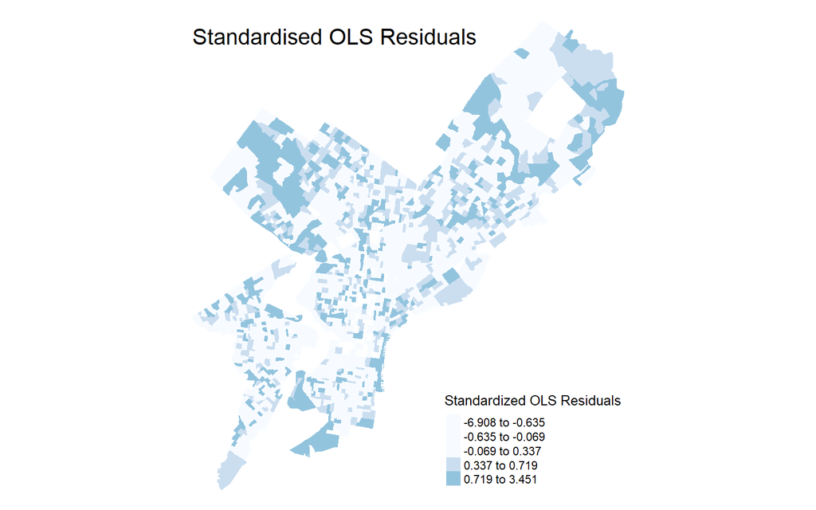

```r
standardised<-rstandard(reg)
resnb<-sapply(queen, function(x) mean(standardised[x]))

shp$standardised <- standardised    #creating a new variable in the shapefile shp.
OLS.Residuals.Map<-tm_shape(shp)+
  tm_fill(col='standardised', style='quantile', title='Standardized OLS Residuals',
          palette ='Blues')+
  tm_layout(frame=FALSE, title = 'Standardised OLS Residuals')
OLS.Residuals.Map
```

First, let’s regress the OLS standardized residuals on the spatial lag of the OLS residuals (i.e., OLS residuals at the queen neighbors). We can see that the beta coefficient of the lagged residuals is significant and positive (0.598, p<0.0001), meaning that there’s a significant level of spatial autocorrelation in the residuals. This is consistent with Moran’s I of the residuals we see below.

```r
#Regressing residuals on their nearest neighbors.
res.lm <- lm(formula=standardised ~ resnb)
summary(res.lm)
```

```
##
## Call:
## lm(formula = standardised ~ resnb)
##
## Residuals:
##     Min      1Q  Median      3Q     Max
## -5.3699 -0.4157  0.0826  0.5578  4.0238
##
## Coefficients:
##             Estimate Std. Error t value            Pr(>|t|)
## (Intercept) 0.007314   0.022610   0.323               0.746
## resnb       0.598182   0.038569  15.509 <0.0000000000000002 ***
## ---
## Signif. codes:  0 '***' 0.001 '**' 0.01 '*' 0.05 '.' 0.1 ' ' 1
##
## Residual standard error: 0.9375 on 1718 degrees of freedom
## Multiple R-squared:  0.1228, Adjusted R-squared:  0.1223
## F-statistic: 240.5 on 1 and 1718 DF,  p-value: < 0.00000000000000022
```

Again, we can use `moran.mc` to generate a Moran’s I statistic and a pseudo p-value.

```r
moran.mc(standardised, queenlist, 999, alternative="two.sided")
```

```
##
##  Monte-Carlo simulation of Moran I
##
## data:  standardised
## weights: queenlist
## number of simulations + 1: 1000
##
## statistic = 0.20532, observed rank = 1000, p-value <
## 0.00000000000000022
## alternative hypothesis: two.sided
```

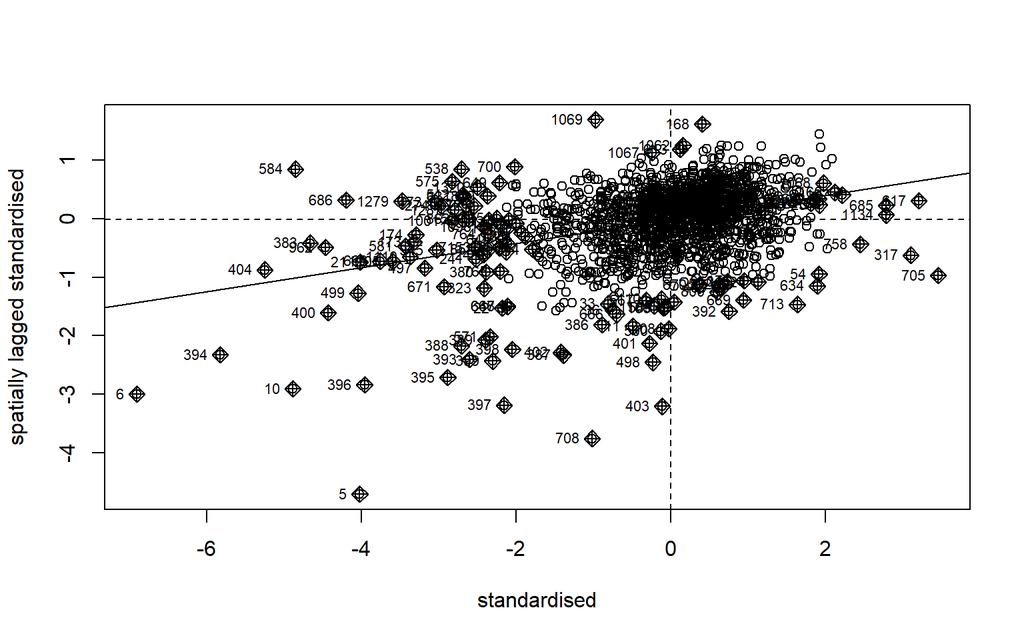

```r
moran.plot(standardised, queenlist)
```

From the above, it is strongly apparent that spatial autocorrelation exists among the regression residuals of the OLS Model. The p-value is very small indicating that Moran’s I is significant. Because there’s clearly spatial autocorrelation in OLS residuals, the OLS Model is inappropriate and we need to consider another method. Here, we will attempt to run the Spatial Lag Model, the Spatial Error Model, and Geographically Weighted Regression.

## Regression Analysis: Spatial Lag Regression

To fit a Spatial Lag Model, we can use the `lagsarlm` function. This function works similarly to the `lm` function we are familiar with. The only key difference lies in the need to specify a weight matrix (neighbor list) created using `nb2listw` function.

From the results, we can see that the rho parameter (spatial lag of LNMEDHHINC), has a value of 0.44383 and is significant. We also get the AIC for the Spatial Lag Model (1207.8) which is substantially smaller than the AIC for the linear model (lm AIC = 1443.3). We also get the log likelihood (-598.91), which is higher (i.e., better) than the value we get in OLS using the `loglik` command (-717.6489). The `LR.Sarlm` command does a likelihood ratio test comparing the Spatial Lag Model to the OLS Model. The null hypothesis here is that the Spatial Lag Model isn’t better than OLS, which we can reject (p-value <0.00001).

```r
lagreg<-lagsarlm(formula=LNMEDHHINC ~ LNMEDHVAL + PCTVACANT, data=shp, queenlist)
summary(lagreg)
```

```
##
## Call:lagsarlm(formula = LNMEDHHINC ~ LNMEDHVAL + PCTVACANT, data = shp,
##     listw = queenlist)
##
## Residuals:
##       Min        1Q    Median        3Q       Max
## -2.215327 -0.153211  0.033143  0.205054  1.332802
##
## Type: lag
## Coefficients: (asymptotic standard errors)
##                Estimate  Std. Error z value              Pr(>|z|)
## (Intercept)  2.86118495  0.23863037 11.9900 < 0.00000000000000022
## LNMEDHVAL    0.26595533  0.01872735 14.2014 < 0.00000000000000022
## PCTVACANT   -0.00506938  0.00098985 -5.1214          0.0000003033
##
## Rho: 0.44383, LR test value: 237.47, p-value: < 0.000000000000000222
## Asymptotic standard error: 0.028132
##     z-value: 15.776, p-value: < 0.000000000000000222
## Wald statistic: 248.89, p-value: < 0.000000000000000222
##
## Log likelihood: -598.9141 for lag model
## ML residual variance (sigma squared): 0.11314, (sigma: 0.33637)
## Number of observations: 1720
## Number of parameters estimated: 5
## AIC: 1207.8, (AIC for lm: 1443.3)
## LM test for residual autocorrelation
## test value: 37.053, p-value: 0.0000000011495
```

```r
LR.Sarlm(lagreg, reg) #Here lagreg is the SL output; reg is the OLS output
```

```
##
##  Likelihood ratio for spatial linear models
##
## data:
## Likelihood ratio = 237.47, df = 1, p-value < 0.00000000000000022
## sample estimates:
## Log likelihood of lagreg    Log likelihood of reg
##                -598.9141                -717.6489
```

```r
#Prints the results of the Breusch-Pagan Test to assess whether heteroscedasticity is present (package: lmtest)
bptest.Sarlm(lagreg, studentize=FALSE)
```

```
##
##  Breusch-Pagan test
##
## data:
## BP = 34.725, df = 2, p-value = 0.00000002881
```

```r
#Prints the results of the Koenker-Bassett Test (also known as the Studentized Breusch-Pagan Test) to assess whether heteroscedasticity is present (package: lmtest)
bptest.Sarlm(lagreg)
```

```
##
##  studentized Breusch-Pagan test
##
## data:
## BP = 11.945, df = 2, p-value = 0.002548
```

```r
#Prints the results of the Jarque-Bera Test to assess whether residuals are normal (package: tseries)
jarque.bera.test(lagreg$residuals)
```

```
##
##  Jarque Bera Test
##
## data:  lagreg$residuals
## X-squared = 1360.1, df = 2, p-value < 0.00000000000000022
```

```r
reslag<-lagreg$residuals
lagMoranMc<-moran.mc(reslag, queenlist,999, alternative="two.sided")
lagMoranMc
```

```
##
##  Monte-Carlo simulation of Moran I
##
## data:  reslag
## weights: queenlist
## number of simulations + 1: 1000
##
## statistic = -0.041474, observed rank = 2, p-value = 0.004
## alternative hypothesis: two.sided
```

## Regression Analysis: Spatial Error Regression

To fit a Spatial Error Model, we use the `errorsarlm` function.

```r
errreg<-errorsarlm(formula=LNMEDHHINC ~ LNMEDHVAL + PCTVACANT, data=shp, queenlist)
reserr<-residuals(errreg)
errresnb<-sapply(queen, function(x) mean(reserr[x]))
summary(errreg)
```

```
##
## Call:errorsarlm(formula = LNMEDHHINC ~ LNMEDHVAL + PCTVACANT, data = shp,
##     listw = queenlist)
##
## Residuals:
##       Min        1Q    Median        3Q       Max
## -1.996941 -0.150038  0.040485  0.210209  1.300334
##
## Type: error
## Coefficients: (asymptotic standard errors)
##               Estimate Std. Error z value              Pr(>|z|)
## (Intercept)  5.9531620  0.2344785 25.3889 < 0.00000000000000022
## LNMEDHVAL    0.3991118  0.0210805 18.9328 < 0.00000000000000022
## PCTVACANT   -0.0043908  0.0010899 -4.0286             0.0000561
##
## Lambda: 0.45391, LR test value: 173.5, p-value: < 0.000000000000000222
## Asymptotic standard error: 0.031143
##     z-value: 14.575, p-value: < 0.000000000000000222
## Wald statistic: 212.42, p-value: < 0.000000000000000222
##
## Log likelihood: -630.899 for error model
## ML residual variance (sigma squared): 0.11721, (sigma: 0.34235)
## Number of observations: 1720
## Number of parameters estimated: 5
## AIC: NA (not available for weighted model), (AIC for lm: 1443.3)
```

```r
LR.Sarlm(errreg, reg)
```

```
##
##  Likelihood ratio for spatial linear models
##
## data:
## Likelihood ratio = 173.5, df = 1, p-value < 0.00000000000000022
## sample estimates:
## Log likelihood of errreg    Log likelihood of reg
##                -630.8990                -717.6489
```

```r
#Prints the results of the Breusch-Pagan Test to assess whether heteroscedasticity is present (package: lmtest)
bptest.Sarlm(errreg, studentize=FALSE)
```

```
##
##  Breusch-Pagan test
##
## data:
## BP = 19.75, df = 2, p-value = 0.00005144
```

```r
#Prints the results of the Koenker-Bassett Test (also known as the Studentized Breusch-Pagan Test) to assess whether heteroscedasticity is present (package: lmtest)
bptest.Sarlm(errreg)
```

```
##
##  studentized Breusch-Pagan test
##
## data:
## BP = 7.1133, df = 2, p-value = 0.02853
```

```r
#Prints the results of the Jarque-Bera Test to assess whether residuals are normal (package: tseries)
jarque.bera.test(errreg$residuals)
```

```
##
##  Jarque Bera Test
##
## data:  errreg$residuals
## X-squared = 1263.8, df = 2, p-value < 0.00000000000000022
```

Now, let’s look at the the Moran’s I of Spatial Error Model residuals. (Again, looking at the map of the Spatial Error Model residuals is an exercise left for the student.) We see that the Spatial Error Model residuals aren’t as spatially autocorrelated as the OLS residuals.

```r
errMoranMc<-moran.mc(reserr, queenlist, 999, alternative="two.sided")
errMoranMc
```

```
##
##  Monte-Carlo simulation of Moran I
##
## data:  reserr
## weights: queenlist
## number of simulations + 1: 1000
##
## statistic = -0.031945, observed rank = 15, p-value = 0.03
## alternative hypothesis: two.sided
```

## Regression Analysis: Geographically Weighted Regression

### **Bandwidth Selection**

Unlike the OLS, SL and SE Models, GWR allows for spatial non-stationarity. It is based on the premise that the relationships between variables aren’t the same at all spatial locations.

Although for the previous analyses, we define **neighbors**, for the GWR analyses, we will define **bandwidths**. The bandwidth can be manually entered by the user, or it can be determined by R through cross-validation. Here, we will be using the `spgwr` package in R to carry out the bandwidth selection and run GWR.

We will use the `gwr.sel` function to calculate the optimal bandwidth for GWR. Let’s examine the parameters specified in the code below.

`formula`: We specify the OLS regression model formula we used in our OLS Model above. This is because a separate OLS equation for every location in the dataset in a GWR Model, and these separate OLS equations incorporate the dependent and explanatory variables of locations falling within the bandwidth of each target location.

`data`: You can specify a dataframe here, or a `SpatialPointsDataFrame` or `SpatialPolgonsDataframe` object that was defined in the package `sp`.

`method`: Here, you specify how an ‘optimal’ bandwidth should be defined. AIC is the approach used here to select a bandwidth that optimises the model AICc (corrected AIC), which is a relative measure of goodness of model fit. Another method you can specify here is cv, which selects a bandwidth that allows for the GWR results to be approximately equal acoss cross-validated folds - here, your objective is a generalisable GWR Model.

`adapt`: TRUE returns a proportion between 0 and 1 of the observations to include in the weighting scheme for an adaptive bandwidth. On the other hand, if a global fixed bandwidth that remains constant for all locations suit your purpose, set this parameter as FALSE.

Let’s start with **adaptive bandwidth**, which varies the distance, but fixes the number of neighbors for each observation. Given that we specified a preference for an adaptive bandwidth optimized based on AICc, the output (despite its labels) is not a distance, but rather, the proportion of observations to be included for each location in the GWR Model. Here, it is recommended that 0.007862703 (or ~0.786%) of the observations be used for each location - the bandwidth should be adapted to capture about 13 observations (0.00786*1720) for each location. You might think this is too few observations to be fitted for each local regression - in this case, the printed AICc measures can serve as a guidance for the proportion you may input in the GWR Model later on. Keep in mind that finding the optimal value of bandwidth takes a while, so be patient while the code runs.

```r
#Setting an adaptive bandwidth
shps <- as(shp, 'Spatial')  #These analyses are easier to do when the data are of the SpatialPolygonsDataFrame class
class (shps)
```

```
## [1] "SpatialPolygonsDataFrame"
## attr(,"package")
## [1] "sp"
```

```r
bw<-gwr.sel(formula=LNMEDHHINC~LNMEDHVAL+PCTVACANT,
            data=shps,
            method = "aic",
            adapt = TRUE)
```

```
## Bandwidth: 0.381966 AIC: 1305.506
## Bandwidth: 0.618034 AIC: 1362.606
## Bandwidth: 0.236068 AIC: 1271.097
## Bandwidth: 0.145898 AIC: 1246.106
## Bandwidth: 0.09016994 AIC: 1223.273
## Bandwidth: 0.05572809 AIC: 1195.597
## Bandwidth: 0.03444185 AIC: 1156.855
## Bandwidth: 0.02128624 AIC: 1108.21
## Bandwidth: 0.01315562 AIC: 1068.727
## Bandwidth: 0.008130619 AIC: 1053.782
## Bandwidth: 0.005024999 AIC: 1074.985
## Bandwidth: 0.009409548 AIC: 1056.238
## Bandwidth: 0.006944377 AIC: 1057.291
## Bandwidth: 0.00828487 AIC: 1053.938
## Bandwidth: 0.00758428 AIC: 1053.802
## Bandwidth: 0.007921936 AIC: 1053.54
## Bandwidth: 0.007862703 AIC: 1053.521
## Bandwidth: 0.007822013 AIC: 1053.522
## Bandwidth: 0.007862703 AIC: 1053.521
```

```r
bw
```

```
## [1] 0.007862703
```

We might also want to create a **fixed bandwidth**. Notice that the output values more closely approximate distance (in the units of the shapfile, i.e., feet) instead of a proportion between 0 and 1.

```r
#setting a fixed bandwidth
bw_fixed<-gwr.sel(formula=LNMEDHHINC~LNMEDHVAL+PCTVACANT,
            data=shps,
            method = "aic",
            adapt = FALSE)
```

```
## Bandwidth: 47374.26 AIC: 1398.429
## Bandwidth: 76576.63 AIC: 1424.654
## Bandwidth: 29326.2 AIC: 1349.39
## Bandwidth: 18171.89 AIC: 1288.041
## Bandwidth: 11278.14 AIC: 1236.538
## Bandwidth: 7017.572 AIC: 1193.669
## Bandwidth: 4384.396 AIC: 1146.309
## Bandwidth: 2757.003 AIC: 1101.766
## Bandwidth: 1751.22 AIC: 1198.759
## Bandwidth: 3378.612 AIC: 1114.164
## Bandwidth: 2372.828 AIC: 1108.797
## Bandwidth: 2805.554 AIC: 1101.993
## Bandwidth: 2737.225 AIC: 1101.729
## Bandwidth: 2723.738 AIC: 1101.722
## Bandwidth: 2724.996 AIC: 1101.722
## Bandwidth: 2725.113 AIC: 1101.722
## Bandwidth: 2725.107 AIC: 1101.722
## Bandwidth: 2725.107 AIC: 1101.722
## Bandwidth: 2725.11 AIC: 1101.722
## Bandwidth: 2725.109 AIC: 1101.722
## Bandwidth: 2725.108 AIC: 1101.722
## Bandwidth: 2725.108 AIC: 1101.722
## Bandwidth: 2725.108 AIC: 1101.722
## Bandwidth: 2725.108 AIC: 1101.722
## Bandwidth: 2725.108 AIC: 1101.722
```

```r
bw_fixed
```

```
## [1] 2725.108
```

**Running GWR** To fit a GWR Model, we use the command `gwr`. Again, specify the formula as used in the previous OLS Model and the bandwidth defined in the earlier step.

We can also set a geographical weighting function for the bandwidth to specify how observations of varying distances from the location should be accounted for. If `gweight=gwr.Gauss`, the weights allocated to distributions vary normally like in a Gaussian (i.e., normal) distribution. If `gwr.bisquare` is specified, observations within the a certain distance threshold (specified by the bandwidth) from the location are weighted as 1, while observations beyond this threshold are weighted as 0.

We can compare the outputs from using an adaptive bandwidth specified by the proportion of observations included in each local regression `(adapt=bw)`, and a fixed bandwidth `(bandwidth=bw_fixed)`.

Below are the results using the **adaptive bandwidth**.

```r
gwrmodel<-gwr(formula=LNMEDHHINC~LNMEDHVAL+PCTVACANT,
              data=shps,
              adapt = bw, #adaptive bandwidth determined by proportion of observations accounted for
              gweight=gwr.Gauss,
              se.fit=TRUE, #to return local standard errors
              hatmatrix = TRUE)
gwrmodel
```

```
## Call:
## gwr(formula = LNMEDHHINC ~ LNMEDHVAL + PCTVACANT, data = shps,
##     gweight = gwr.Gauss, adapt = bw, hatmatrix = TRUE, se.fit = TRUE)
## Kernel function: gwr.Gauss
## Adaptive quantile: 0.007862703 (about 13 of 1720 data points)
## Summary of GWR coefficient estimates at data points:
##                     Min.     1st Qu.      Median     3rd Qu.        Max.
## X.Intercept. -2.03175118  4.30431275  5.73286844  7.20531650 11.06778564
## LNMEDHVAL    -0.08286663  0.27805552  0.41888004  0.55664161  1.12049003
## PCTVACANT    -0.08738042 -0.00977209 -0.00470761  0.00039279  0.02211028
##               Global
## X.Intercept.  5.6510
## LNMEDHVAL     0.4315
## PCTVACANT    -0.0092
## Number of data points: 1720
## Effective number of parameters (residual: 2traceS - traceS'S): 225.0455
## Effective degrees of freedom (residual: 2traceS - traceS'S): 1494.955
## Sigma (residual: 2traceS - traceS'S): 0.3184033
## Effective number of parameters (model: traceS): 157.9225
## Effective degrees of freedom (model: traceS): 1562.077
## Sigma (model: traceS): 0.3114872
## Sigma (ML): 0.2968433
## AICc (GWR p. 61, eq 2.33; p. 96, eq. 4.21): 1053.521
## AIC (GWR p. 96, eq. 4.22): 861.0162
## Residual sum of squares: 151.5594
## Quasi-global R2: 0.6347951
```

Below are the results using the **fixed bandwidth**.

```r
gwrmodel_fixed<-gwr(formula=LNMEDHHINC~LNMEDHVAL+PCTVACANT,
              data=shps,
              bandwidth = bw_fixed, #fixed bandwidth
              gweight=gwr.Gauss,
              se.fit=TRUE, #to return local standard errors
              hatmatrix = TRUE)
gwrmodel_fixed
```

```
## Call:
## gwr(formula = LNMEDHHINC ~ LNMEDHVAL + PCTVACANT, data = shps,
##     bandwidth = bw_fixed, gweight = gwr.Gauss, hatmatrix = TRUE,
##     se.fit = TRUE)
## Kernel function: gwr.Gauss
## Fixed bandwidth: 2725.108
## Summary of GWR coefficient estimates at data points:
##                     Min.     1st Qu.      Median     3rd Qu.        Max.
## X.Intercept. -16.1262473   4.1776598   5.7099683   7.1945038  13.4989876
## LNMEDHVAL     -0.2445834   0.2814575   0.4182731   0.5651933   2.3245849
## PCTVACANT     -0.1547116  -0.0090242  -0.0045781  -0.0003024   0.0659854
##               Global
## X.Intercept.  5.6510
## LNMEDHVAL     0.4315
## PCTVACANT    -0.0092
## Number of data points: 1720
## Effective number of parameters (residual: 2traceS - traceS'S): 237.6103
## Effective degrees of freedom (residual: 2traceS - traceS'S): 1482.39
## Sigma (residual: 2traceS - traceS'S): 0.3212628
## Effective number of parameters (model: traceS): 170.9678
## Effective degrees of freedom (model: traceS): 1549.032
## Sigma (model: traceS): 0.3142761
## Sigma (ML): 0.2982479
## AICc (GWR p. 61, eq 2.33; p. 96, eq. 4.21): 1101.722
## AIC (GWR p. 96, eq. 4.22): 890.3002
## Residual sum of squares: 152.9971
## Quasi-global R2: 0.6313309
```

Notice that when we construct our GWR Model, the output from `gwr.sel` (where `adapt=TRUE`) should be specified for the parameter `adapt`. On the other hand, if we were interested in a fixed bandwidth, the output from `gwr.sel` (where `adapt=FALSE`) should be specified for the parameter `bandwidth`. Also notice the difference in the results. We seem to be getting a better fit (based on AIC), less error (based on Residual sum of squares), and a slightly better global R<sup>2</sup> using the GWR Model with an adaptive bandwidth. **Keep in mind that when comparing the GWR Model to OLS, Spatial Lag and Spatial Error, you should use the AIC and not the AICc.**

**Presenting GWR Output Using Adaptive Bandwidth** We can look at a summary of the coefficients of the local regressions, stored in the `SDF` object within `thegwrmodel`. Note in particular the minimum and maximum values of the Local R<sup>2</sup> (0.05789 - 0.75169). There are no negative values, meaning that this output, unlike the output we get in some versions of ArcGIS Pro, is correct.

```r
summary(gwrmodel$SDF)
```

```
## Object of class SpatialPolygonsDataFrame
## Coordinates:
##         min       max
## x 2660604.8 2750171.3
## y  207610.6  304858.8
## Is projected: NA
## proj4string : [NA]
## Data attributes:
##      sum.w        X.Intercept.      LNMEDHVAL          PCTVACANT
##  Min.   :15.94   Min.   :-2.032   Min.   :-0.08287   Min.   :-0.0873804
##  1st Qu.:23.75   1st Qu.: 4.304   1st Qu.: 0.27806   1st Qu.:-0.0097721
##  Median :25.83   Median : 5.733   Median : 0.41888   Median :-0.0047076
##  Mean   :26.60   Mean   : 5.628   Mean   : 0.42758   Mean   :-0.0057903
##  3rd Qu.:28.42   3rd Qu.: 7.205   3rd Qu.: 0.55664   3rd Qu.: 0.0003928
##  Max.   :82.64   Max.   :11.068   Max.   : 1.12049   Max.   : 0.0221103
##  X.Intercept._se  LNMEDHVAL_se      PCTVACANT_se          gwr.e
##  Min.   :0.417   Min.   :0.03691   Min.   :0.002276   Min.   :-2.12779
##  1st Qu.:1.006   1st Qu.:0.09035   1st Qu.:0.004919   1st Qu.:-0.13725
##  Median :1.466   Median :0.13302   Median :0.006560   Median : 0.02338
##  Mean   :1.615   Mean   :0.14588   Mean   :0.007866   Mean   :-0.00141
##  3rd Qu.:2.050   3rd Qu.:0.18633   3rd Qu.:0.009363   3rd Qu.: 0.17374
##  Max.   :6.271   Max.   :0.54688   Max.   :0.031691   Max.   : 1.20816
##       pred           pred.se           localR2        X.Intercept._se_EDF
##  Min.   : 9.202   Min.   :0.02840   Min.   :0.05789   Min.   :0.4263
##  1st Qu.: 9.980   1st Qu.:0.05163   1st Qu.:0.24333   1st Qu.:1.0281
##  Median :10.232   Median :0.06172   Median :0.34231   Median :1.4984
##  Mean   :10.245   Mean   :0.06740   Mean   :0.35696   Mean   :1.6507
##  3rd Qu.:10.522   3rd Qu.:0.07704   3rd Qu.:0.45616   3rd Qu.:2.0956
##  Max.   :12.172   Max.   :0.25217   Max.   :0.75169   Max.   :6.4103
##  LNMEDHVAL_se_EDF  PCTVACANT_se_EDF     pred.se.1
##  Min.   :0.03773   Min.   :0.002326   Min.   :0.02904
##  1st Qu.:0.09236   1st Qu.:0.005028   1st Qu.:0.05278
##  Median :0.13597   Median :0.006706   Median :0.06309
##  Mean   :0.14912   Mean   :0.008041   Mean   :0.06890
##  3rd Qu.:0.19047   3rd Qu.:0.009571   3rd Qu.:0.07875
##  Max.   :0.55902   Max.   :0.032395   Max.   :0.25777
```

We can also map the standardized coefficients. The higher the absolute value of the ratio between the coefficient and the standard error, the more plausible it is that the relationship between the predictor and the dependent variable is significant at the location.

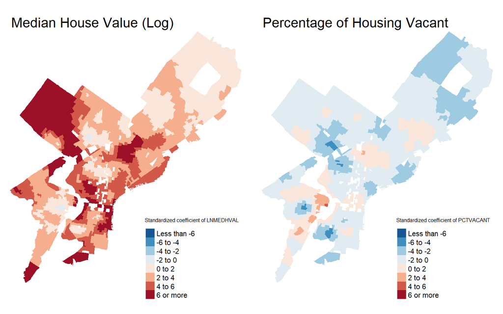

```r
gwrresults<-as.data.frame(gwrmodel$SDF)
shps$coefLNMEDHVALst<-gwrresults$LNMEDHVAL/gwrresults$LNMEDHVAL_se
shps$coefPCTVACANTst<-gwrresults$PCTVACANT/gwrresults$PCTVACANT_se

shps$gwrE<-gwrresults$gwr.e
shps$localR2<-gwrresults$localR2

coefLNMEDHVAL<-tm_shape(shps)+
  tm_fill(col='coefLNMEDHVALst', breaks=c(-Inf, -6, -4, -2, 0, 2, 4, 6, Inf), title='Standardized coefficient of LNMEDHVAL',
          palette ='-RdBu')+
  tm_layout(frame=FALSE, title = 'Median House Value (Log)')

coefPCTVACANT<-tm_shape(shps)+
  tm_fill(col='coefPCTVACANTst', breaks=c(-Inf, -6, -4, -2, 0, 2, 4, 6, Inf), title='Standardized coefficient of PCTVACANT',
          palette='-RdBu')+
  tm_layout(frame=FALSE, title = 'Percentage of Housing Vacant')

tmap_arrange(coefLNMEDHVAL, coefPCTVACANT, ncol=2)
```

And we can also look at the spatial distribution of the local R-squares. We can see that the two predictors do a good job explaining the variance in our dependent variable in NW Philadelphia, but not in many other parts of the city.

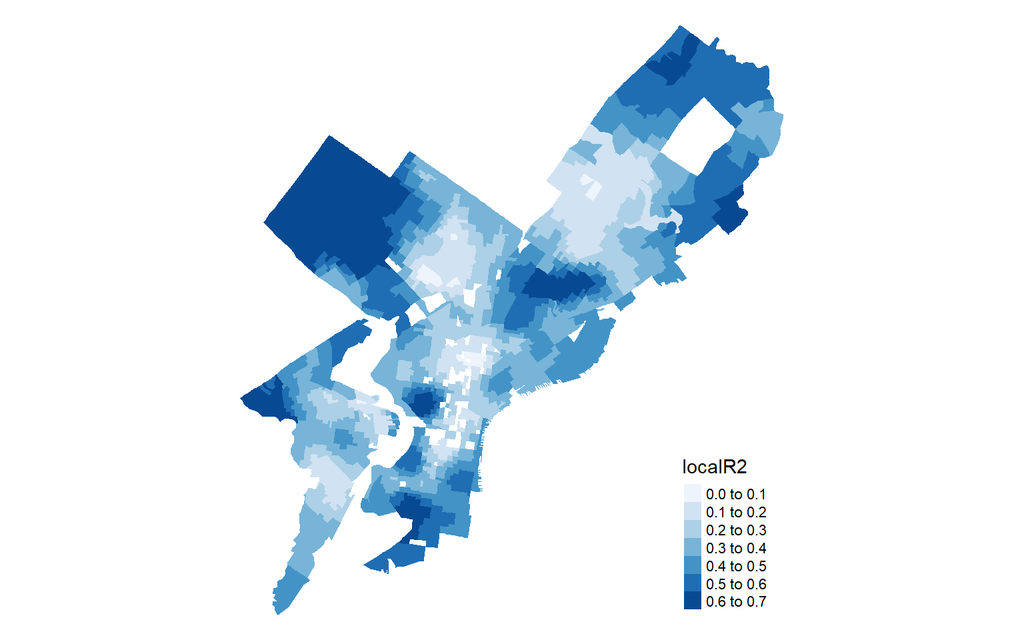

```r
tm_shape(shps)+
  tm_fill(col='localR2',  breaks=c(0, 0.1, 0.2, 0.3, 0.4, 0.5, 0.6, 0.7), n=5, palette = 'Blues')+
  tm_layout(frame=FALSE)
```

Finally, we can also look at the spatial autocorrelation in GWR residuals. This exercise is left for the student (spoiler alert: there’s much less autocorrelation in GWR residuals than in OLS residuals). Note that the residuals are extracted above using the command `shp$gwrE<-gwrresults$gwr.e`.

## Model comparison (exercise is left for the student)

We can do the following to compare all 4 models:

1. Look at the Moran’s I of the residuals from each model and choose the model with the lowest (absolute) Moran’s I
2. Compare the AIC values from each model and choose the model with the lowest value

In addition, we can do the following to compare the Spatial Lag Model to OLS:

1. Compare the log likelihoods; the model with the higher value is the better one.
2. Examine the results of the likelihood ratio test; if it’s significant, the Spatial Lag Model is better than OLS.

In addition, we can do the following to compare the Spatial Error Model to OLS:

1. Compare the log likelihoods; the model with the higher value is the better one.
2. Examine the results of the likelihood ratio test; if it’s significant, the Spatial Error Model is better than OLS.

Lastly, we can also do the following to compare GWR to OLS:

1. Compare the R<sup>2</sup> from OLS with the Quasi-global R<sup>2</sup> from GWR; the model with the higher value is the better one.
2. Examine whether there’s spatial variability in standardized coefficients or local R<sup>2</sup> values. If there is, it might mean that a single global regression might not capture the varying spatial relationships between the dependent variable and the predictors.